# Módulo Gráficos

Práctica guiada

## Gráfico de barras con variables numéricas

### Supongamos que queremos comparar la media del ingreso por la ocupación principal de las y los asalariados según la condición de registro.

**1. Cargo las librerías con las que voy a trabajar:**

```r
library(eph)
library(tidyverse)
library(questionr)
library(ggthemes)
```

**2. Descargamos la base de datos con la que vamos a trabajar:**

```r
base <- get_microdata(year = 2018, trimester = 4, type = "individual")
```

**3. Estructuramos la base para obtener la información que queremos visualizar:**

```r
medias <- base %>%
  filter(ESTADO == 1, CAT_OCUP == 3) %>%
  mutate(condicion_registro = factor(PP07H,
                                     levels = c(1, 2),
                                     labels = c( "Registrado", "No registrado"))) %>%
  group_by(condicion_registro) %>%
  summarise(media = wtd.mean(P21))
```

**4. Graficamos**

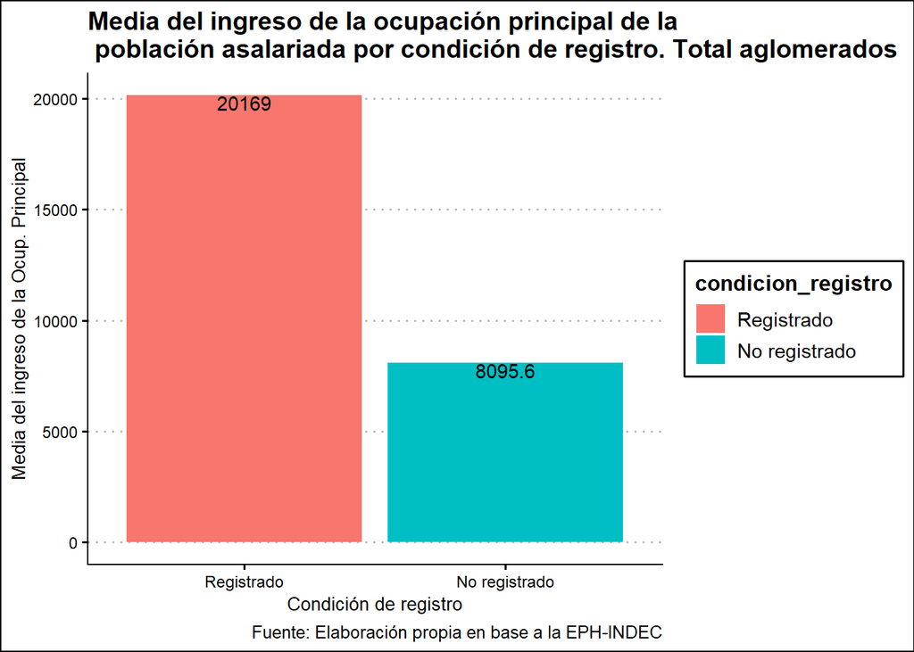

```r
medias %>%
  ggplot(aes(x = condicion_registro,
             y = media,
             fill = condicion_registro)) +
  geom_bar(stat = "identity") +
  geom_text(aes(label = round(media, 1)),
            vjust = 1) +
  labs(title = "Media del ingreso de la ocupación principal de la \n población asalariada por condición de registro. Total aglomerados",
       x = "Condición de registro",
       y = "Media del ingreso de la Ocup. Principal",
       caption = "Fuente: Elaboración propia en base a la EPH-INDEC") +
  theme_clean()
```

```r
  #ggsave(filename = "barras_media.png", width = 6, height = 5)
```

- *Con `labs` agregamos las etiquetas al gráfico (título, subtítulo, nombre de los ejes, notas al pie, etc.).*
  - *Con `\n` podemos “partir” el título tantas veces como querramos.*

*Con `geom_text()` agregamos las etiquetas de los valores que toma la variable en el gráfico*

## Gráfico de barras para variables categóricas

- Intentemos graficar cómo se distribuye la población en función del nivel educativo de las personas y el sexo:
- Al ser ambas variables cualitativas, tendremos que estructura la base en fución:

```r
base_graf <- base %>%
  mutate(nivel_educativo = factor(NIVEL_ED,
                                  levels = c(7, 1:6),
                                  labels = c("Sin instrucción", "Primaria incompleta",
                                             "Primaria completa", "Secundaria incompleta",
                                             "Secundaria completa", "Superior incompleta",
                                             "Superior completa")),
         sexo               = factor(CH04,
                                     levels = c(1, 2),
                                     labels = c("Varón", "Mujer"))) %>%
  select(nivel_educativo, sexo, PONDERA)
```

## Parámetro de posición (`position = ""`)

**position = “stack”**

- Posiciona de forma apilada cada una de las categorías, acumulando cantidades.

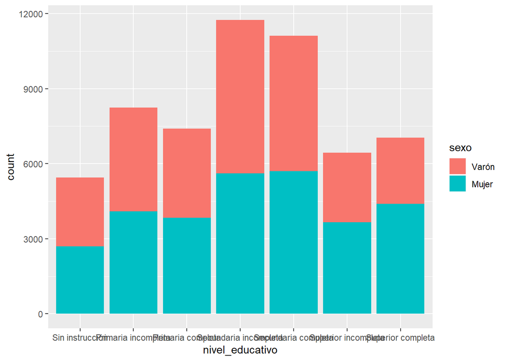

```r
ggplot(data = base_graf) +
  geom_bar(aes(x = nivel_educativo,
               fill = sexo),
           position = "stack")
```

### - **position = “fill”**

- Posiciona de forma apilada cada una de las categorías, con límites de 0 a 1 (para comparación de proporciones)

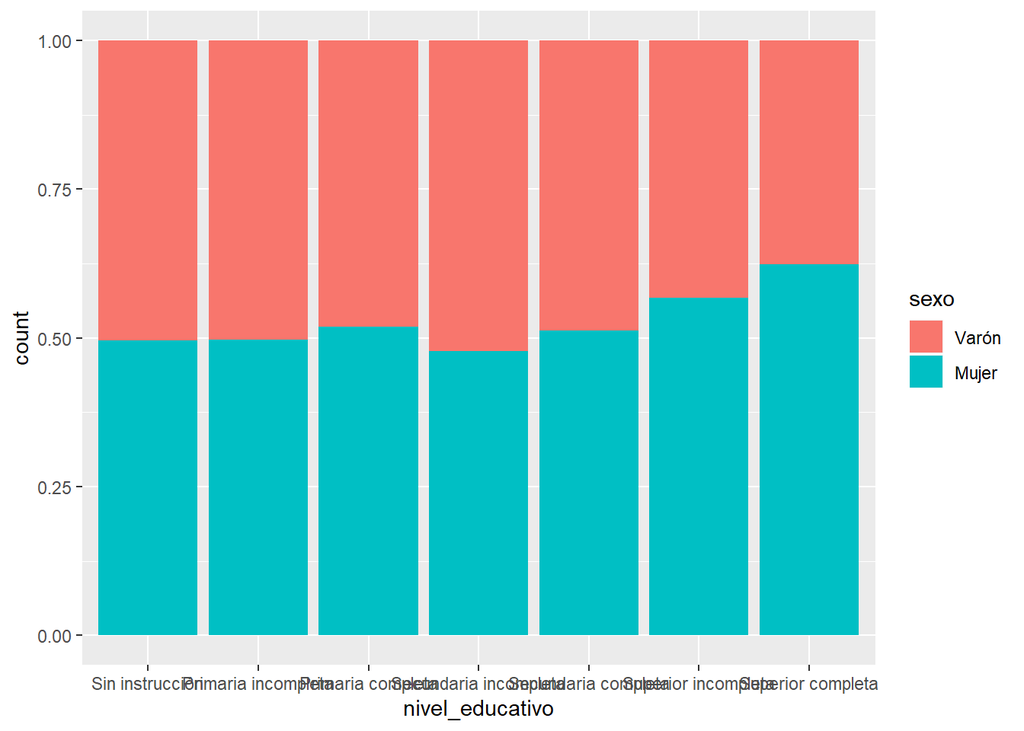

```r
ggplot(data = base_graf) +
  geom_bar(aes(x = nivel_educativo,
               fill = sexo),
           position = "fill")
```

### - **position = “dodge”**

- Posiona de forma vertical las barras en función de las categorías

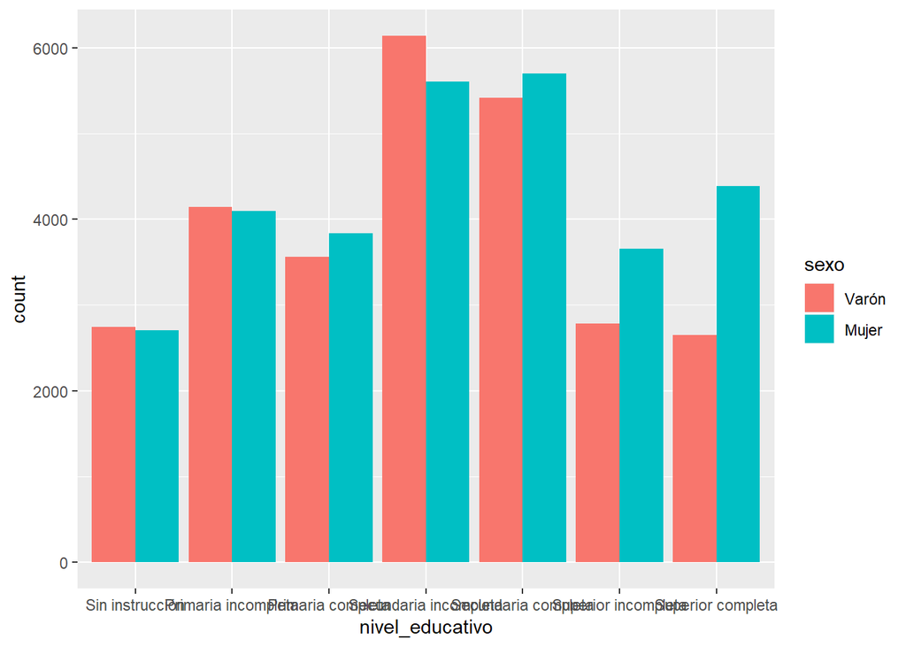

```r
ggplot(data = base_graf) +
  geom_bar(aes(x = nivel_educativo,
               fill = sexo),
           position = "dodge")
```

### *¿Y si invertimos el análisis?*

### **position = “stack”**

- Posiciona de forma apilada cada una de las categorías, acumulando cantidades.

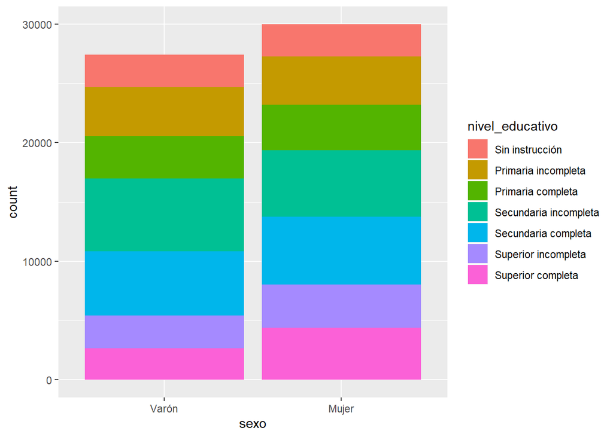

```r
ggplot(data = base_graf) +
  geom_bar(aes(x = sexo,
               fill = nivel_educativo),
           position = "stack")
```

### **position = “fill”**

- Posiciona de forma apilada cada una de las categorías, con límites de 0 a 1 (para comparación de proporciones)

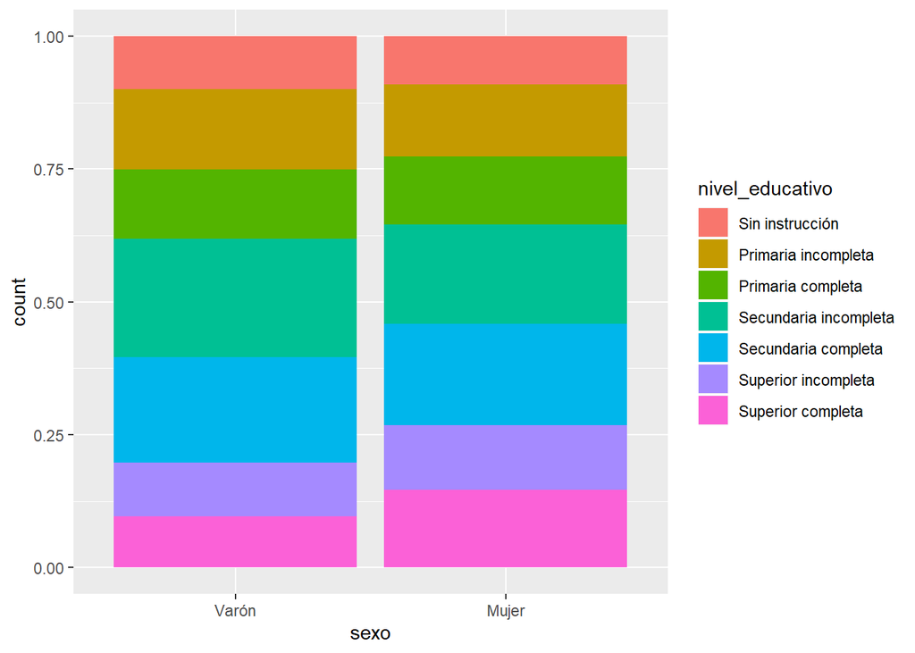

```r
ggplot(data = base_graf) +
  geom_bar(aes(x = sexo,
               fill = nivel_educativo),
           position = "fill")
```

### **position = “dodge”**

- Posiona de forma vertical las barras en función de las categorías

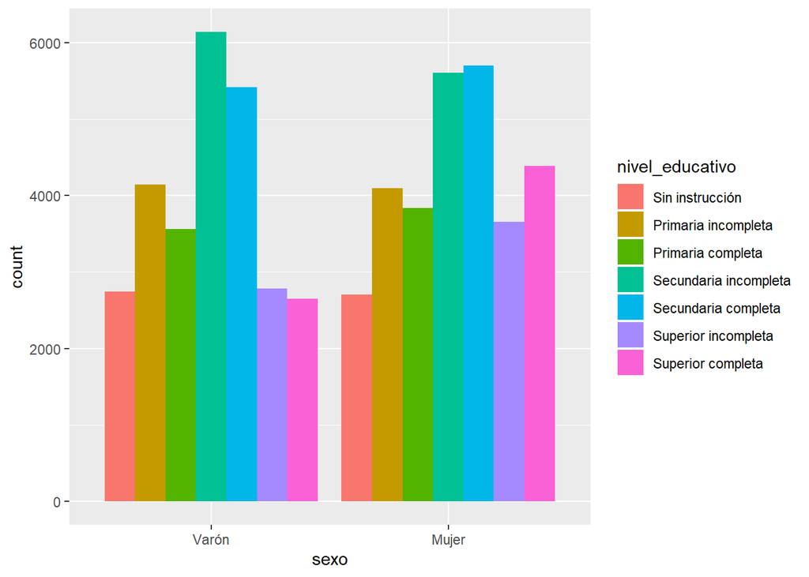

```r
ggplot(data = base_graf) +
  geom_bar(aes(x = sexo,
               fill = nivel_educativo),
           position = "dodge")
```

### _En el mismo gráfico podemos ir editando algo del estilo:

Con `scale_fill_viridis_d` cambiamos la paleta de colores a la escala *“viridis”*, diseñada por expertos en visualización de la información, pensada para lucir bien y poder ser leída incluso por gente con daltonismo.

```r
base_graf2 <- base_graf %>%
  calculate_tabulates("sexo", "nivel_educativo", weights = "PONDERA") %>%
  gather(key = nivel_educativo, value = poblacion, 2:8) %>%
  rename(sexo = `sexo/nivel_educativo`) %>%
  group_by(sexo) %>%
  mutate(pob_porcentaje = poblacion / sum(poblacion)*100)


sum(base_graf2$pob_porcentaje[base_graf2$sexo=="Varón"])
```

```
## [1] 100
```

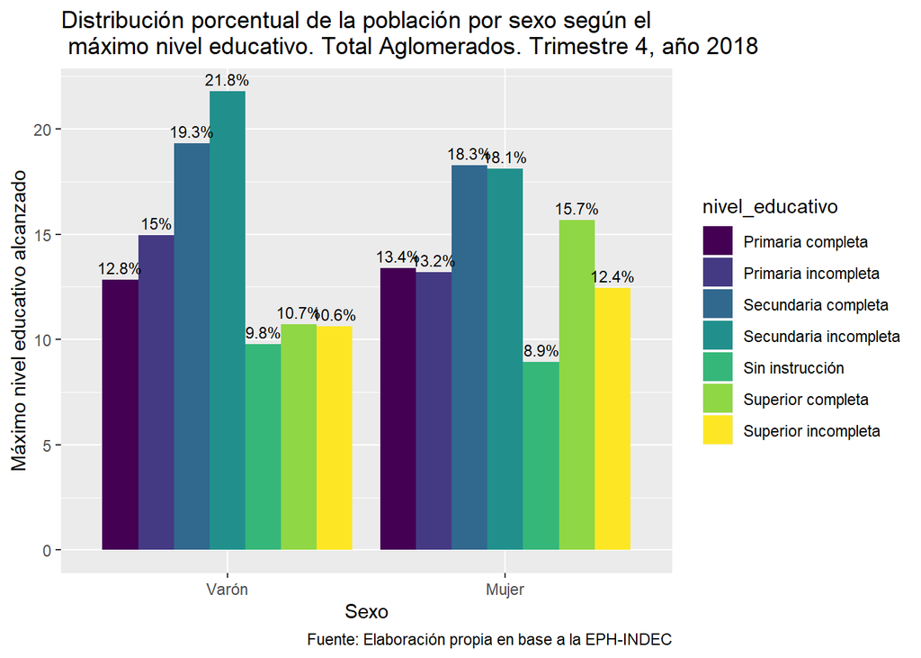

```r
ggplot(data = base_graf2) +
  geom_bar(aes(x = sexo,
               y = pob_porcentaje,
               fill = nivel_educativo),
           position = "dodge",
           stat     = "identity") +
  geom_text(aes(x = sexo,
                y = pob_porcentaje,
                group = nivel_educativo,
                label = paste0(round(pob_porcentaje,1), "%")),
            position=position_dodge(width=0.9),
            vjust = -0.5,
            size = 3) +
  scale_fill_viridis_d() +
  labs(title = "Distribución porcentual de la población por sexo según el \n máximo nivel educativo. Total Aglomerados. Trimestre 4, año 2018",
       x = "Sexo",
       y = "Máximo nivel educativo alcanzado",
       caption = "Fuente: Elaboración propia en base a la EPH-INDEC")
```

- Posiciona de forma apilada cada una de las categorías, con límites de 0 a 1 (para comparación de proporciones). Agregamos etiquetas y estilo.

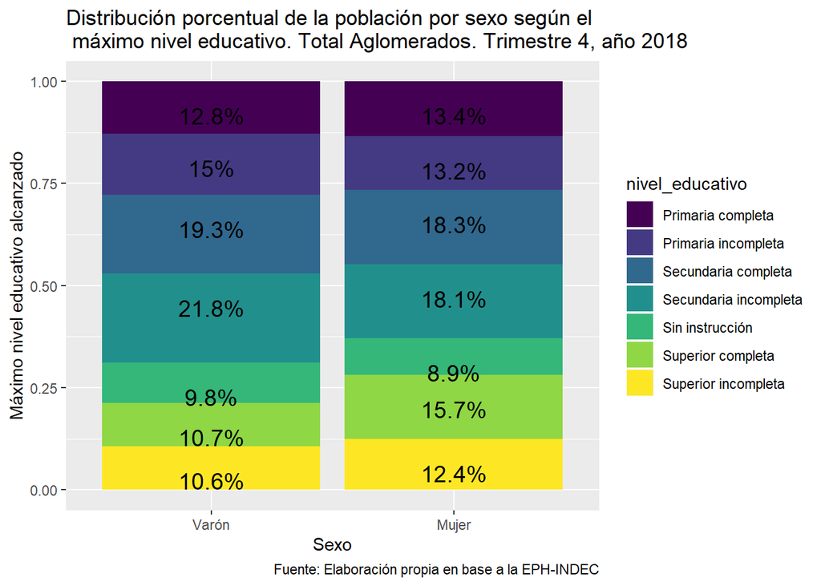

```r
ggplot(data = base_graf2) +
  geom_bar(aes(x = sexo,
               y = pob_porcentaje,
               fill = nivel_educativo),
           position = "fill",
           stat = "identity") +
  geom_text(aes(x = sexo,
               y = pob_porcentaje,
               group = nivel_educativo,
               label = paste0(round(pob_porcentaje,1), "%")),
           position = "fill",
           vjust = 2.5,
           size = 5) +
  scale_fill_viridis_d() +
  labs(title = "Distribución porcentual de la población por sexo según el \n máximo nivel educativo. Total Aglomerados. Trimestre 4, año 2018",
       x = "Sexo",
       y = "Máximo nivel educativo alcanzado",
       caption = "Fuente: Elaboración propia en base a la EPH-INDEC")
```

### Hacer un gráfico de lineas, evolución en el tiempo.

Bajo varias bases para construir una serie de tiempo:

```r
library(eph)
library(tidyverse)
base2018t1 <- get_microdata(year = 2018, trimester = 1, type = "individual")
base2018t2 <- get_microdata(year = 2018, trimester = 2, type = "individual")
base2018t3 <- get_microdata(year = 2018, trimester = 3, type = "individual")
base2018t4 <- get_microdata(year = 2018, trimester = 4, type = "individual")
```

Fusiono bases:

```r
base_tot <- rbind(base2018t1, base2018t2, base2018t3, base2018t4) %>%
  mutate(periodo = paste0(ANO4, "t", TRIMESTRE))

# Chequeo fusión y armado de variable `periodo`
table(base_tot$periodo)
```

```
##
## 2018t1 2018t2 2018t3 2018t4
##  57951  57835  56879  57418
```

Armo tabla con datos para tasa de no registro de la población asalariada en el tiempo

```r
tabulado <- base_tot %>%
  filter(ESTADO == 1, CAT_OCUP == 3) %>%
  group_by(periodo, CH04) %>%
  summarise(poblacion_no_registrada = sum(PONDERA[PP07H==2]),
            tasa                    = poblacion_no_registrada / sum(PONDERA) * 100) %>%
  select(-poblacion_no_registrada)
tabulado
```

```
## # A tibble: 8 x 3
## # Groups:   periodo [4]
##   periodo  CH04  tasa
##   <chr>   <int> <dbl>
## 1 2018t1      1  31.9
## 2 2018t1      2  36.4
## 3 2018t2      1  31.9
## 4 2018t2      2  37.1
## 5 2018t3      1  32.1
## 6 2018t3      2  37.0
## 7 2018t4      1  32.9
## 8 2018t4      2  38.1
```

Graficamos:

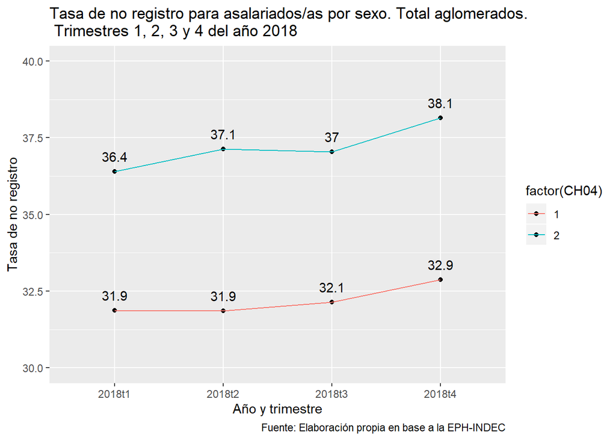

```r
ggplot(tabulado) +
  aes(x = periodo,
      y = tasa,
      group = factor(CH04),
      fill = factor(CH04),
      label = round(tasa,1)) +
  geom_point() +
  geom_line(aes(color = factor(CH04))) +
  scale_y_continuous(limits = c(30, 40)) +
  geom_text(vjust = -1) +
  labs(title = "Tasa de no registro para asalariados/as por sexo. Total aglomerados. \n Trimestres 1, 2, 3 y 4 del año 2018",
       x = "Año y trimestre",
       y = "Tasa de no registro",
       caption = "Fuente: Elaboración propia en base a la EPH-INDEC")
```